# Содержание

Исследование рынка российского кинопроката =

Изучим рынок российского кинопроката и выявим текущие тренды. Уделим внимание фильмам, которые получили государственную поддержку. Попробуем ответить на вопрос, насколько такие фильмы интересны зрителю. Набор данных содержит информацию о прокатных удостоверениях, сборах и государственной поддержке фильмов, а также информацию с сайта КиноПоиск.

### Откроем файлы с данными и изучим информацию

```python
import pandas as pd
import numpy as np
import matplotlib.pyplot as plt
import seaborn as sns
import warnings
warnings.filterwarnings(action = 'ignore')
pd.options.display.max_columns = 40
pd.options.display.float_format = '{:,.2f}'.format
```

```python
# загрузим первый набор с данными, посмотрим информацию о датасете.
df = pd.read_csv('C:/Users/User/Downloads/mkrf_movies.csv')
```

```python
df.head(5)
```

|  | title | puNumber | show_start_date | type | film_studio | production_country | director | producer | age_restriction | refundable_support | nonrefundable_support | budget | financing_source | ratings | genres |
| --- | --- | --- | --- | --- | --- | --- | --- | --- | --- | --- | --- | --- | --- | --- | --- |
| 0 | Открытый простор | 221048915 | 2015-11-27T12:00:00.000Z | Художественный | Тачстоун Пикчерз, Кобальт Пикчерз, Бикон Пикче... | США | Кевин Костнер | Дэвид Валдес, Кевин Костнер, Джейк Эбертс | «18+» - запрещено для детей | NaN | NaN | NaN | NaN | 7.2 | боевик,драма,мелодрама |
| 1 | Особо важное задание | 111013716 | 2016-09-13T12:00:00.000Z | Художественный | Киностудия "Мосфильм" | СССР | Е.Матвеев | NaN | «6+» - для детей старше 6 лет | NaN | NaN | NaN | NaN | 6.6 | драма,военный |
| 2 | Особо опасен | 221038416 | 2016-10-10T12:00:00.000Z | Художественный | Юниверсал Пикчерз, Кикстарт Продакшнз, Марк Пл... | США | Тимур Бекмамбетов | Джим Лемли, Джейсон Нетер, Марк Е.Платт, Яйн Смит | «18+» - запрещено для детей | NaN | NaN | NaN | NaN | 6.8 | фантастика,боевик,триллер |
| 3 | Особо опасен | 221026916 | 2016-06-10T12:00:00.000Z | Художественный | Юниверсал Пикчерз, Кикстарт Продакшнз, Марк Пл... | США | Тимур Бекмамбетов | Джим Лемли, Джейсон Нетер, Марк Е.Платт, Яйн Смит | «18+» - запрещено для детей | NaN | NaN | NaN | NaN | 6.8 | фантастика,боевик,триллер |
| 4 | Особо опасен | 221030815 | 2015-07-29T12:00:00.000Z | Художественный | Юниверсал Пикчерз, Кикстарт Продакшнз, Марк Пл... | США | Тимур Бекмамбетов | Джим Лемли, Джейсон Нетер, Марк Е.Платт, Яйн Смит | «18+» - запрещено для детей | NaN | NaN | NaN | NaN | 6.8 | фантастика,боевик,триллер |

```python
df.info()
```

```
<class 'pandas.core.frame.DataFrame'>
RangeIndex: 7486 entries, 0 to 7485
Data columns (total 15 columns):
 #   Column                 Non-Null Count  Dtype
---  ------                 --------------  -----
 0   title                  7486 non-null   object
 1   puNumber               7486 non-null   object
 2   show_start_date        7486 non-null   object
 3   type                   7486 non-null   object
 4   film_studio            7468 non-null   object
 5   production_country     7484 non-null   object
 6   director               7477 non-null   object
 7   producer               6918 non-null   object
 8   age_restriction        7486 non-null   object
 9   refundable_support     332 non-null    float64
 10  nonrefundable_support  332 non-null    float64
 11  budget                 332 non-null    float64
 12  financing_source       332 non-null    object
 13  ratings                6519 non-null   object
 14  genres                 6510 non-null   object
dtypes: float64(3), object(12)
memory usage: 877.4+ KB
```

```python
# загрузим второй датасет с данными, посмотрим информацию о датасете
df1 = pd.read_csv('C:/Users/User/Downloads/mkrf_shows.csv')
```

```python
df1.head(10)
```

|  | puNumber | box_office |
| --- | --- | --- |
| 0 | 111000113 | 2,450.00 |
| 1 | 111000115 | 61,040.00 |
| 2 | 111000116 | 153,030,013.40 |
| 3 | 111000117 | 12,260,956.00 |
| 4 | 111000118 | 163,684,057.79 |
| 5 | 111000119 | 4,293,649.51 |
| 6 | 111000212 | 200.00 |
| 7 | 111000216 | 355,567.00 |
| 8 | 111000313 | 710.00 |
| 9 | 111000314 | 1,607,970.00 |

```python
df1.info()
```

```
<class 'pandas.core.frame.DataFrame'>
RangeIndex: 3158 entries, 0 to 3157
Data columns (total 2 columns):
 #   Column      Non-Null Count  Dtype
---  ------      --------------  -----
 0   puNumber    3158 non-null   int64
 1   box_office  3158 non-null   float64
dtypes: float64(1), int64(1)
memory usage: 49.5 KB
```

Очевидно, что объединение датасетов будет происходить по столбцу `puNumber`. Так как данные уаказанного столбца имеют разные типы данных, перед объединением приведем столбцы к числовому формату, где необходимо

```python
#изменение формата на числовой
df['puNumber'] = pd.to_numeric( df['puNumber'],errors = 'coerce')
```

Объединим данные в один датасет:

```python
data = df.merge(df1,on = 'puNumber', how = 'left')
```

```python
# проверим информацию
data.info()
```

```
<class 'pandas.core.frame.DataFrame'>
Int64Index: 7486 entries, 0 to 7485
Data columns (total 16 columns):
 #   Column                 Non-Null Count  Dtype
---  ------                 --------------  -----
 0   title                  7486 non-null   object
 1   puNumber               7485 non-null   float64
 2   show_start_date        7486 non-null   object
 3   type                   7486 non-null   object
 4   film_studio            7468 non-null   object
 5   production_country     7484 non-null   object
 6   director               7477 non-null   object
 7   producer               6918 non-null   object
 8   age_restriction        7486 non-null   object
 9   refundable_support     332 non-null    float64
 10  nonrefundable_support  332 non-null    float64
 11  budget                 332 non-null    float64
 12  financing_source       332 non-null    object
 13  ratings                6519 non-null   object
 14  genres                 6510 non-null   object
 15  box_office             3158 non-null   float64
dtypes: float64(5), object(11)
memory usage: 994.2+ KB
```

Произошло успешное слияние данных. Дальнейшяя работа будет осуществляться над датасетом `data`

```python
data.head()
```

|  | title | puNumber | show_start_date | type | film_studio | production_country | director | producer | age_restriction | refundable_support | nonrefundable_support | budget | financing_source | ratings | genres | box_office |
| --- | --- | --- | --- | --- | --- | --- | --- | --- | --- | --- | --- | --- | --- | --- | --- | --- |
| 0 | Открытый простор | 221,048,915.00 | 2015-11-27T12:00:00.000Z | Художественный | Тачстоун Пикчерз, Кобальт Пикчерз, Бикон Пикче... | США | Кевин Костнер | Дэвид Валдес, Кевин Костнер, Джейк Эбертс | «18+» - запрещено для детей | NaN | NaN | NaN | NaN | 7.2 | боевик,драма,мелодрама | NaN |
| 1 | Особо важное задание | 111,013,716.00 | 2016-09-13T12:00:00.000Z | Художественный | Киностудия "Мосфильм" | СССР | Е.Матвеев | NaN | «6+» - для детей старше 6 лет | NaN | NaN | NaN | NaN | 6.6 | драма,военный | NaN |
| 2 | Особо опасен | 221,038,416.00 | 2016-10-10T12:00:00.000Z | Художественный | Юниверсал Пикчерз, Кикстарт Продакшнз, Марк Пл... | США | Тимур Бекмамбетов | Джим Лемли, Джейсон Нетер, Марк Е.Платт, Яйн Смит | «18+» - запрещено для детей | NaN | NaN | NaN | NaN | 6.8 | фантастика,боевик,триллер | NaN |
| 3 | Особо опасен | 221,026,916.00 | 2016-06-10T12:00:00.000Z | Художественный | Юниверсал Пикчерз, Кикстарт Продакшнз, Марк Пл... | США | Тимур Бекмамбетов | Джим Лемли, Джейсон Нетер, Марк Е.Платт, Яйн Смит | «18+» - запрещено для детей | NaN | NaN | NaN | NaN | 6.8 | фантастика,боевик,триллер | NaN |
| 4 | Особо опасен | 221,030,815.00 | 2015-07-29T12:00:00.000Z | Художественный | Юниверсал Пикчерз, Кикстарт Продакшнз, Марк Пл... | США | Тимур Бекмамбетов | Джим Лемли, Джейсон Нетер, Марк Е.Платт, Яйн Смит | «18+» - запрещено для детей | NaN | NaN | NaN | NaN | 6.8 | фантастика,боевик,триллер | NaN |

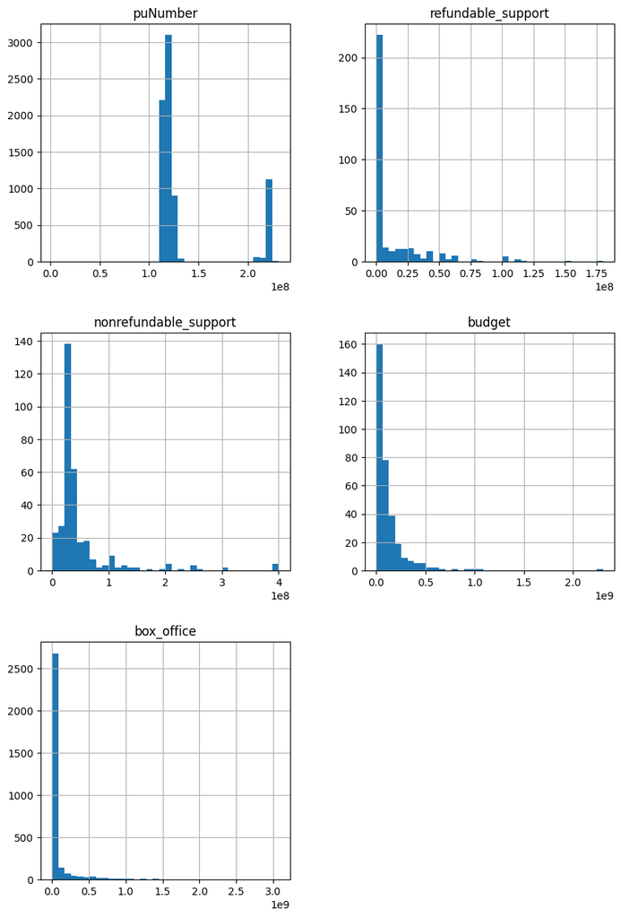

```python
# построим гистограммы для каждого числового столбца
data.hist(figsize = (10,15), bins = 36);
```

Видны некоторые аномалии , возвратная и невозвратная части бюджета имеют показатели около 0, так же как и данные общего бюджета, возможно это типичные значения для указанных столбцов или ошибочные значения

### Предобработка данных

#### Пропуски

```python
# запишем в переменную количество строк до обработки
start_row, a = data.shape
```

```python
# исследуем количество пропусков
data.info()
```

```
<class 'pandas.core.frame.DataFrame'>
Int64Index: 7486 entries, 0 to 7485
Data columns (total 16 columns):
 #   Column                 Non-Null Count  Dtype
---  ------                 --------------  -----
 0   title                  7486 non-null   object
 1   puNumber               7485 non-null   float64
 2   show_start_date        7486 non-null   object
 3   type                   7486 non-null   object
 4   film_studio            7468 non-null   object
 5   production_country     7484 non-null   object
 6   director               7477 non-null   object
 7   producer               6918 non-null   object
 8   age_restriction        7486 non-null   object
 9   refundable_support     332 non-null    float64
 10  nonrefundable_support  332 non-null    float64
 11  budget                 332 non-null    float64
 12  financing_source       332 non-null    object
 13  ratings                6519 non-null   object
 14  genres                 6510 non-null   object
 15  box_office             3158 non-null   float64
dtypes: float64(5), object(11)
memory usage: 994.2+ KB
```

```python
def null_value(data):
    try:
        (
            (data.isna().mean()*100)
            .to_frame()
            .rename(columns = {0:'space'})
            .query('space > 0')
            .sort_values(by = 'space', ascending = True)
            .plot(kind= 'barh', figsize=(20,5), rot = 0, legend = False, fontsize = 16)
            .set_title('Пропуски данных' + "\n", fontsize = 22, color = 'SteelBlue')
        );
    except:
        print('Пропусков нет')
```

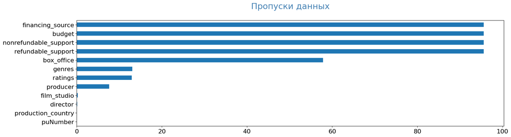

```python
# визуализируем количество пропусков
null_value(data)
```

Внушительное количество пропусков наблюдается в столбце `financing_source`, и связанных с ним столбцов `budget`и обоих его частей(возвратной и невозвратной), что является ожидаемым результатом исходя из специфики анализируемой информации. Данные о кассовых сборах есть лишь у менее половины фильмов. Прорпуски в столбца `ratings` и `genres` составляют менее 15%. Остальные столбцы не имеют или имеют минимальные пропуски в данных. Некоторые пропуски можно заполнить синтетическими данными.

```python
# найдем и посчитаем количество явных дубликатов, 0 - явных дубликатов нет.
data.duplicated().sum()
```

```
0
```

- Заменим пропуски в столбце `financing_source`

```python
# выведем список уникальных значений столбца
data['financing_source'].unique()
```

```
array([nan, 'Министерство культуры', 'Фонд кино',
       'Министерство культуры, Фонд кино'], dtype=object)
```

Очевидно пропуски связаны с отсутствием финансирования посредством госструктур. Заменим пропуски на "Иное финансирование"

```python
data['financing_source'] = data['financing_source'].fillna('Иное финансирование')
```

- Пропуски в столбце `genres`

Пропуски в столбце можно заменить с поправкой на тип фильма и возрастные ограничения.

```python
data['type'].unique()
```

```
array(['Художественный', 'Анимационный', 'Прочие', 'Документальный',
       'Научно-популярный', ' Художественный', ' Анимационный',
       'Музыкально-развлекательный'], dtype=object)
```

```python
# есть ошибки, исправим правописание
data.loc[data['type'] == " Художественный", 'type'] = 'Художественный'
data.loc[data['type'] == " Анимационный", 'type'] = 'Анимационный'
```

```python
#если тип фильма анимационный, можно с уверенностью заполнить пропуски общим словом "мультфильм"
data.loc[(data['genres'].isna())&(data['type'] == "Анимационный"), 'genres'] = 'мультфильм'
```

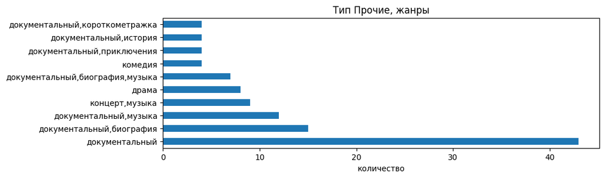

```python
# проверим какие категории жанра чаще всего встречаются в тип "Прочие"
data.query('type == "Прочие"')['genres'].value_counts().head(10).plot(kind = 'barh', figsize = (10,3))
plt.xlabel('количество')
plt.title('Тип Прочие, жанры');
```

```python
# заменим пропуски в типе фильмов "Прочие" на подходящий жанр - "документальный"
data.loc[(data['genres'].isna())&(data['type'] == "Прочие"), 'genres'] = 'документальный'
```

Пропуски в типе 'Художественный' в связи с жанровым разнообразием стоит заполнить с поправкой на возрастной ценз.

```python
# для типа "художественный" и возрастного ценза - для любой аудитории заменим пропуски на жанр "семейный"
data.loc[(data['genres'].isna())&(data['type'] == "Художественный")&\
         (data['age_restriction'] =="«0+» - для любой зрительской аудитории"),'genres'] = 'семейный'
```

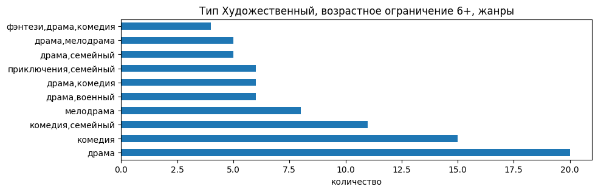

```python
# посмотрим типичные жанры для типа "Художественный" и с возрастным ограничением старше 6 лет
data.query('type == "Художественный" and age_restriction =="«6+» - для детей старше 6 лет"')['genres'].value_counts().head(10)\
.plot(kind = 'barh',figsize = (10,3))
plt.xlabel('количество')
plt.title('Тип Художественный, возрастное ограничение 6+, жанры');
```

```python
# для типа "художественный" и возрастного ценза - для детей старше 6 лет заменим пропуски на жанр "драма, комедия"
data.loc[(data['genres'].isna())&(data['type'] == "Художественный")&\
         (data['age_restriction'] =="«6+» - для детей старше 6 лет"),'genres'] = 'драма, комедия'
```

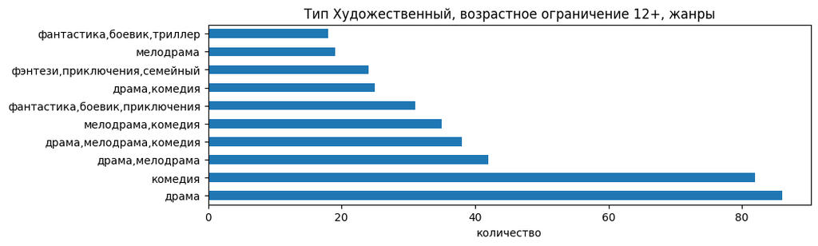

```python
# посмотрим типичные жанры для типа "Художественный" и возрастного ограничения старше 12 лет
data.query('type == "Художественный" and age_restriction =="«12+» - для детей старше 12 лет"')['genres'].value_counts()\
.head(10).plot(kind = 'barh',figsize = (10,3))
plt.xlabel('количество')
plt.title('Тип Художественный, возрастное ограничение 12+, жанры');
```

```python
# для типа "художественный" и возрастного ценза - для детей старше 12 лет заменим пропуски на жанр "драма, комедия"
data.loc[(data['genres'].isna())&(data['type'] == "Художественный")&\
         (data['age_restriction'] =="«12+» - для детей старше 12 лет"),'genres'] = 'драма, комедия'
```

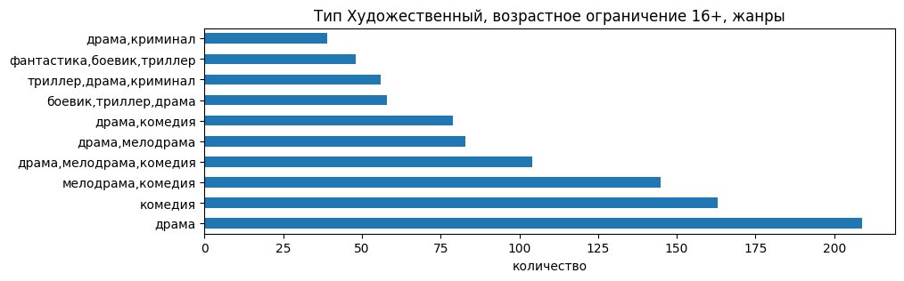

```python
# посмотрим типичные жанры для типа "Художественный" и возрастного ограничения 16+ лет
data.query('type == "Художественный" and age_restriction =="«16+» - для детей старше 16 лет"')['genres'].value_counts()\
.head(10).plot(kind = 'barh',figsize = (10,3))
plt.xlabel('количество')
plt.title('Тип Художественный, возрастное ограничение 16+, жанры');
```

```python
# для типа "художественный" и возрастного ценза - для детей старше 16 лет заменим пропуски на жанр "драма, комедия"
data.loc[(data['genres'].isna())&(data['type'] == "Художественный")&\
         (data['age_restriction'] =="«16+» - для детей старше 16 лет"),'genres'] = 'драма, комедия'
```

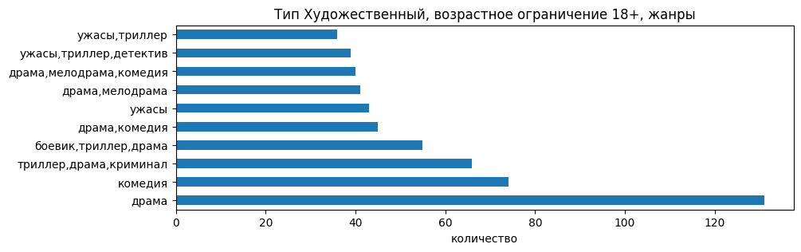

```python
# посмотрим типичные жанры для типа "Художественный" и запрещенного для детей, 18+
data.query('type == "Художественный" and age_restriction =="«18+» - запрещено для детей"')['genres'].value_counts()\
.head(10).plot(kind = 'barh',figsize = (10,3))
plt.xlabel('количество')
plt.title('Тип Художественный, возрастное ограничение 18+, жанры');
```

```python
# для типа "художественный" и возрастного ценза - 18+ заполним пропуски на жанр "драма"
data.loc[(data['genres'].isna())&(data['type'] == "Художественный")&\
         (data['age_restriction'] =="«18+» - запрещено для детей"),'genres'] = 'драма'
```

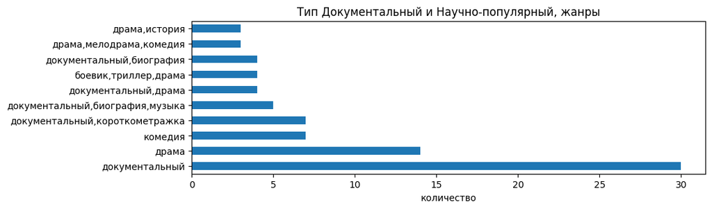

```python
data.query('type == "Документальный" or type == "Научно-популярный"')['genres'].value_counts()\
.head(10).plot(kind = 'barh',figsize = (10,3))
plt.xlabel('количество')
plt.title('Тип Документальный и Научно-популярный, жанры');
```

```python
# для типа "документальный" и 'научно-популярный'заполним пропуски на жанр "документальный"
data.loc[(data['genres'].isna())&((data['type'] == "Документальный")|(data['type'] == "Научно-популярный")),'genres']\
= 'документальный'
```

- Удалим пропуски в столбцах `production_country` и `puNumber`.

```python
data = data.dropna(subset = ['production_country'])
data = data.dropna(subset = ['puNumber'])
```

- Рассмторим пропуски в столбце `producer` в зависимости от страны-производителя

```python
data.query('producer.isna()')['production_country'].value_counts().head(5)
```

```
СССР              342
Россия             37
Великобритания     33
США                24
СССР               20
Name: production_country, dtype: int64
```

Пропуски в некоторых данных скорее всего связаны с годом производства фильмов.Например пропуски в имени продюсера в СССР связаны с отсутствием оного как отдельного исполняющего.Режиссер испонял функции продюсирования, которые как отдельный вид деятельности зародились лишь в 90гг 20века уже в постсовесткое время. Произведем заполнение пропусков в столбце продюсер для страны-производителя СССР(или совместно с СССР) именем режиссера.

```python
# произведем заполнение пропусков, возьмем в расчет ошибочное правописание
data.loc[data["production_country"].str.contains("СССР","CCCP")\
             &(data['producer'].isna()),'producer'] = data['director']
```

Вывод:

В данных `financing_source` пропуски связаны с отсутствием категории иного финансирования,соответственно добавлена новая категория "Иное финансирование". Пропуски в столбце `genre`заполнены типичными жанрами для определенного типа, в случае с типом "Художественный" проведено дополнительное ранжирование по возрастному цензу. Столбец `box_office` содержит данные о сборах в рублях. Оценить предполагаемый сбор невозможно, пропуски остаются. Данные `rating`предполагают потребительскую оценку и не связаны с другими данными. Имеющиеся пропуски в столбцах `production_country` и `puNumber` удалены ввиду малого количества

#### Изменение типов данных

```python
# приведем тип столбца к datetime
data['show_start_date'] = pd.to_datetime(data['show_start_date'])
```

```python
# сменим тип данных на строковый для удобства работы
data['production_country']=data['production_country'].astype('str')
data['genres'] = data['genres'].astype('str')
data['director'] = data['director'].astype('str')
```

```python
# проверим уникальные значения столбца ratings
data['ratings'].unique()
```

```
array(['7.2', '6.6', '6.8', '7.7', '8.3', '8.0', '7.8', '8.1', '7.1',
       '6.0', '7.4', '5.8', '8.7', '6.3', '6.9', '5.0', '4.3', '7.3',
       '7.0', '6.4', nan, '8.2', '7.5', '6.7', '7.9', '5.9', '6.2', '5.6',
       '6.5', '2.4', '7.6', '6.1', '8.6', '8.5', '8.8', '5.5', '5.1',
       '5.7', '5.4', '99%', '4.4', '4.5', '5.3', '4.1', '8.4', '2.6',
       '3.8', '4.6', '4.8', '4.0', '3.0', '1.6', '4.2', '5.2', '4.7',
       '4.9', '3.9', '2.7', '3.3', '2.9', '28%', '3.7', '1.4', '3.1',
       '97%', '3.5', '3.2', '2.8', '1.5', '2.1', '2.5', '9.2', '3.4',
       '1.1', '3.6', '83%', '64%', '91%', '94%', '62%', '79%', '90%',
       '19%', '88%', '1.0', '89%', '1.3', '1.9', '1.8', '1.2', '1.7',
       '9.0', '98%', '8.9', '9.1'], dtype=object)
```

Рейтинг имеет некоторые строковые значения с символом процента, указывающего на формат. Переведем значения процентов в баллы и преобразуем ошибочную запись в числовой формат.

```python
# в столбце rating имеются строки, напишем функцию для перевода в числовой формат
def converts(digit):
    try:
        digit = float(digit)
        return digit
    except:
        digit  = float(digit[0] + '.' + digit[1])
        return digit
```

```python
# сменим формат столбца
data['ratings'] = data['ratings'].apply(converts)
```

#### Неявные дубликаты

Рассмотрим категориальные данные датасета

- Столбец `title`.

Посчитаем количество уникальных значений

```python
len(data['title'].unique())
```

```
6769
```

Столбец имеет некторое количество повторений в названии фильма, что совершенно нормально при разных номерах прокатных удостоверений.

- В столбеце `production_country` находятся данные о стране-происхождении киноленты, проведем работу по выявлению неявных дубликатов.

```python
# посчитаем количество значений
data['production_country'].nunique()
```

```
950
```

```python
# выведем список уникальных значений, отсортировав по длине строки
sorted(data['production_country'].unique(), key = len)
```

```
['США',
 'КНР',
 'ЮАР',
 'СЩА',
 'CША',
 'СССР',
 'Чили',
 'Иран',
 'США ',
 'Перу',
 '2019',
 'Чехия',
 'Дания',
 'Индия',
 'СССР ',
 ' СССР',
 'Иран ',
 'Корея',
 'Китай',
 'Япония',
 'Италия',
 'Россия',
 'Швеция',
 'Канада',
 'Турция',
 'СССР  ',
 ' СССР ',
 'Грузия',
 'Греция',
 'Польша',
 'Франция',
 'Австрия',
 'Гонконг',
 'Испания',
 'Украина',
 'США-ОАЭ',
 'США-ЮАР',
 'Израиль',
 'Италия ',
 'Армения',
```

[output cut: 895 more lines]

```
 'Великобритания - США - Канада - Бельгия - Нидерланды - Австрия - Германия',
 'Израиль - Франция - Германия - Палестина - США - Австрия - Великобритания',
 'Нидерланды - США - Германия - Канада - Франция - Ирландия - Великобритания',
 'Испания - Франция - Нидерланды - Германия - Бельгия - Великобритания - Канада',
 'Франция - Канада - Н.Зеландия - США - Нидерланды - Германия - Швеция - Россия',
 'Франция - Германия - Швеция - США - Чехия - Словакия - Великобритания - Нидерланды',
 'Испания - Швейцария - Великобритания - Германия - Новая Зеландия - Нидерланды - Канада',
 'Босния и Герцеговина - Франция - Великобритания - Германия - Словения - Бельгия - Сербия',
 'Дания - Швеция - Великобритания - Франция - Германия - Нидерланды - Норвегия - Финляндия',
 'Великобритания - Испания - Непал - Индия - Венгрия - Гонконг - Германия - Дания - Бахрейн',
 'Дания, Швеция, Великобритания, Франция, Германия, Норвегия, Финляндия, Нидерланды, Италия',
 'Мексика - Эквадор - Канада - США - Франция - Малайзия - Италия - Аргентина - Германия - Индия  ',
 'Великобритания - Франция - Италия - Индия - Дания - КНР - Бангладеш - Камбоджа - Гаити - Уганда',
 'Япония - Великобритания - Швейцария - Ирландия - Дания - Франция - Польша - Австралия - Канада  ',
 'Норвегия - Азербайджан - Россия - Колумбия - Великобритания - Венгрия - Румыния - Франция - Грузия']
```

Видим ошибки правописания, использование множества пробелов.

```python
# уберем пробелы в начале и конце строки
data['production_country'] = data['production_country'].str.strip()
```

```python
# произведем замену ошибочного написания
for i in ['CША', 'СШA', 'СЩА','Сша']:
    data['production_country'] = data['production_country'].str.replace(i,"США")
```

```python
data['production_country'] = data['production_country'].replace('Норвения','Норвегия')
```

```python
data['production_country'] = data['production_country'].str.replace("КНР", "Китай")
```

```python
data['production_country'] = data['production_country'].replace('2019','Германия')
```

```python
data['production_country'] = data['production_country'].str.replace('Объединенные Арабские Эмираты','ОАЭ')
```

```python
data['production_country'] = data['production_country'].str.replace('Белоруссия','Беларусь')
```

```python
data['production_country'] = data['production_country'].str.replace('Германя','Германия')
```

```python
data['production_country'] = data['production_country'].str.replace('Республика','')
```

Данные имеют разные стили написания, приведем все к одному виду. С помощью цикла на основе каждого уникального значения столбца `production_country` создадим список стран, входящих в строку, предварительно убрав все разделители. Отсортируем список в алфавитном порядке, и соединим заново в строку с помощью выбранного разделителя. В цикле произведем замену значений столбца с помощью логической индексации

```python
for symbol in [',', '-']:
    for name in data['production_country'].unique():
        res = []
        for tot in [symbol.strip(' ,-, --') for symbol in name.split(symbol)]:
            res.append(tot)
        data.loc[data['production_country'] == name,'production_country'] = ' - '.join(sorted(res))
```

```python
# отсоритируем список по превым 6 символам и проверим данные еще раз
sorted(data['production_country'].unique(), key = lambda x: x[:6])
```

```
[' - Великобритания - Германия - Канада - США - Швеция',
 'Австралия - США',
 'Австралия',
 'Австралия - Бразилия - Великобритания - Германия - США - Франция',
 'Австралия - Великобритания - США',
 'Австралия - Германия - Финляндия',
 'Австралия - США - Франция',
 'Австралия - Великобритания',
 'Австралия - Дания - США',
 'Австралия - США - Турция',
 'Австралия - Великобритания - Дания - Ирландия - Канада - Польша - Франция - Швейцария - Япония',
 'Австралия - Германия',
 'Австралия - Бельгия - Великобритания - Индия',
 'Австралия - Великобритания - Германия - Ирландия - Канада - Куба - США',
 'Австралия - Великобритания - Германия - Канада - США',
 'Австралия - Ирландия',
 'Австралия - Германия - Индия - Канада - США - Франция',
 'Австралия - Великобритания - Новая Зеландия - США',
 'Австралия - Германия - Канада - США - Франция',
 'Австралия - Франция',
 'Австралия - Канада - США',
 'Австралия - Германия - США',
 'Австралия - Мексика - США',
 'Австралия - Колумбия',
 'Австралия - Дания - Канада - Норвегия - США',
 'Австралия - Индия - США',
 'Австралия - Канада',
 'Австрия - Великобритания - США - Франция',
 'Австрия - Германия - Италия - США - Франция',
 'Австрия',
 'Австрия - Великобритания - Германия',
 'Австрия - Германия',
 'Австрия - Германия - Франция',
 'Австрия - Россия - Финляндия',
 'Австрия - Франция',
 'Австрия - Великобритания - Германия - Ю.Корея - Япония',
 'Австрия - Бельгия - Великобритания - Германия - Нидерланды - Франция',
 'Австрия - Германия - Ирландия',
 'Австрия - Дания - Ирландия - Нидерланды - Норвегия - Финляндия - Швеция',
 'Австрия - Бельгия - Великобритания - Германия - Канада - Нидерланды - США',
```

[output cut: 602 more lines]

```
 'Финляндия - Франция',
 'Франция',
 'Франция - Швейцария',
 'Франция - Чили',
 'Франция - Швеция',
 'Хорватия',
 'Чехия',
 'Чехословакия',
 'Чили',
 'Швейцария',
 'Швеция',
 'Эстония',
 'ЮАР',
 'Южная Корея',
 'Япония']
```

```python
# посчитаем количество оставшихся значений
data['production_country'].nunique()
```

```
657
```

- Проверим столбец `puNumber` на дубликаты

```python
data[data['puNumber'].duplicated()]
```

|  | title | puNumber | show_start_date | type | film_studio | production_country | director | producer | age_restriction | refundable_support | nonrefundable_support | budget | financing_source | ratings | genres | box_office |
| --- | --- | --- | --- | --- | --- | --- | --- | --- | --- | --- | --- | --- | --- | --- | --- | --- |
| 4639 | Иоанна - женщина на папском престоле /По роман... | 221,154,310.00 | 2010-12-17 12:00:00+00:00 | Художественный | Константин Фильм, А Эр Ди Дегето Фильм, Дюне ... | Великобритания - Германия - Испания - Италия | Зенке Вортманн | Оливер Бербен, Дорис Д.Хайнце, Фарук Элтан | «16+» - для детей старше 16 лет | NaN | NaN | NaN | Иное финансирование | 7.60 | драма,мелодрама,история | NaN |
| 5068 | Анализируй то! | 221,054,410.00 | 2010-05-25 12:00:00+00:00 | Художественный | Уорнер Бразерс, Виллидж Роадшоу Пикчерз, Эн-Пи... | США | Гарольд Реймис | Джейн Розенталь, Паул Уэйнстейн | «12+» - для детей старше 12 лет | NaN | NaN | NaN | Иное финансирование | 6.80 | комедия,криминал | NaN |

```python
# выведем строки с одинаковым прокатным удостоверением
data.loc[(data['puNumber'] == 221154310)|(data['puNumber'] == 221054410)]
```

|  | title | puNumber | show_start_date | type | film_studio | production_country | director | producer | age_restriction | refundable_support | nonrefundable_support | budget | financing_source | ratings | genres | box_office |
| --- | --- | --- | --- | --- | --- | --- | --- | --- | --- | --- | --- | --- | --- | --- | --- | --- |
| 4638 | Как жениться и остаться холостым | 221,154,310.00 | 2010-12-17 12:00:00+00:00 | Художественный | Ше Вам, Скрипт Ассосье, Тэ Фэ 1 Фильм Продюксь... | Франция | Эрик Лартиго | Амандин Било, Алан Шаба | «16+» - для детей старше 16 лет | NaN | NaN | NaN | Иное финансирование | 7.00 | мелодрама,комедия | NaN |
| 4639 | Иоанна - женщина на папском престоле /По роман... | 221,154,310.00 | 2010-12-17 12:00:00+00:00 | Художественный | Константин Фильм, А Эр Ди Дегето Фильм, Дюне ... | Великобритания - Германия - Испания - Италия | Зенке Вортманн | Оливер Бербен, Дорис Д.Хайнце, Фарук Элтан | «16+» - для детей старше 16 лет | NaN | NaN | NaN | Иное финансирование | 7.60 | драма,мелодрама,история | NaN |
| 5067 | Анализируй это! | 221,054,410.00 | 2010-05-25 12:00:00+00:00 | Художественный | Уорнер Бразерс, Вилладж Роудшоу Филмз ЛТД | Австралия - США | ХЭрольд Рэмис | Джейн Розенталь, Пола Уейнстейн | «16+» - для детей старше 16 лет | NaN | NaN | NaN | Иное финансирование | 7.40 | комедия,криминал | NaN |
| 5068 | Анализируй то! | 221,054,410.00 | 2010-05-25 12:00:00+00:00 | Художественный | Уорнер Бразерс, Виллидж Роадшоу Пикчерз, Эн-Пи... | США | Гарольд Реймис | Джейн Розенталь, Паул Уэйнстейн | «12+» - для детей старше 12 лет | NaN | NaN | NaN | Иное финансирование | 6.80 | комедия,криминал | NaN |

Фильмы с одиниковым номером прокатного удостоверения являются разными, что является некоторым допущением, удаление строк нецелесообразно.

Вывод:

Проведена работа по выявлению неявных дубликатов. В столбцах с названием фильма дубликаты допустимы, в связи со спецификой кинопроката. В столбцах указывающих на страну и тип фильмов, выявлены дубликаты, произведена замена. Информация о режисcере и продюсере содержит большой обьем информации, обработка и поиск дубликатов не является целесообразным в рамках данного исследования.

#### Изучение параметров

```python
# напишем функцию для возврата предельных значений , характерных для столбца
def moustache(data):
    q3 = data.quantile(0.75)
    q1 = data.quantile(0.25)
    delta = q3 - q1
    if q1 - (delta*1.5) < data.min():
        return (data.min(), q3 + (delta*1.5))
    else:
        return (q1 - (delta*1.5), q3 + (delta*1.5))
```

- Данные столбца `ratings`

```python
data['ratings'].describe()
```

```
count   6,517.00
mean        6.49
std         1.11
min         1.00
25%         5.90
50%         6.60
75%         7.20
max         9.90
Name: ratings, dtype: float64
```

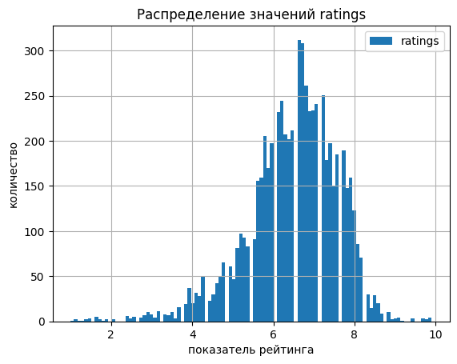

```python
data['ratings'].hist(bins = 105, legend = True, grid = True)
plt.title('Распределение значений ratings')
plt.xlabel('показатель рейтинга')
plt.ylabel('количество');
```

Чаще всего фильмы оценивают между 5,5 и 7 баллами.Максимальная оценка 9.9, минимальная 1 балл.

- Исследуем столбец `refundable_support`

Данные столбца включают информацию только для фильмов с поддержкой госбюджета и содержит информацию о возвратной части бюджета, которая в свою очередь может равняться 0

```python
# определим границы нормальных значений
moustache(data['refundable_support'])
```

```
(0.0, 37500000.0)
```

```python
#посмотрим на медианное и среднее значения
data['refundable_support'].describe()
```

```
count           332.00
mean     11,864,457.83
std      24,916,555.26
min               0.00
25%               0.00
50%               0.00
75%      15,000,000.00
max     180,000,000.00
Name: refundable_support, dtype: float64
```

Медианное значение равно 0, значит большая часть данных равна 0

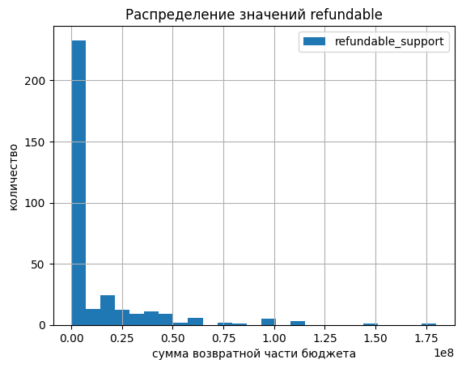

```python
# отобразим на гистограмме количественное распределение значений
data['refundable_support'].hist(bins = 25, legend = True);
plt.title('Распределение значений refundable')
plt.xlabel('сумма возвратной части бюджета')
plt.ylabel('количество');
```

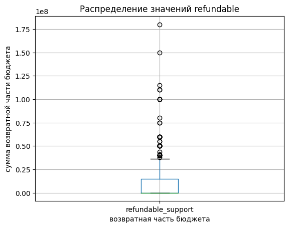

```python
# построим боксплот для визуализации данных
data['refundable_support'].plot(kind = 'box', grid = True);
plt.title('Распределение значений refundable')
plt.xlabel('возвратная часть бюджета')
plt.ylabel('сумма возвратной части бюджета');
```

Минимальное значение для возвратной части бюджета это 0 рублей, макимальное значение 180 млн.рублей. Медианное значение составляет 0 рублей .Среднее арифметическое сильно отличается от медианы, что говорит о неоднородности данных.

- Исследуем столбец с информацией о невозвратной части бюджета `nonrefundable_support`

```python
# определим границы нормальных значений
moustache(data['nonrefundable_support'])
```

```
(1937500.0, 63437500.0)
```

```python
# описание основных метрик данных
data['nonrefundable_support'].describe()
```

```
count           332.00
mean     48,980,988.89
std      59,980,117.92
min               0.00
25%      25,000,000.00
50%      30,000,000.00
75%      40,375,000.00
max     400,000,000.00
Name: nonrefundable_support, dtype: float64
```

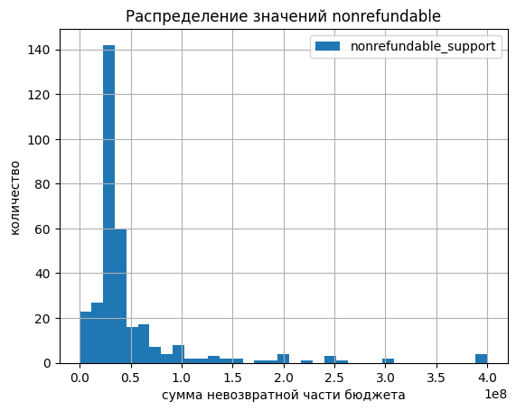

```python
# построим гистограмму распределения значений
data['nonrefundable_support'].hist(bins = 35, legend = True);
plt.title('Распределение значений nonrefundable')
plt.xlabel('сумма невозвратной части бюджета')
plt.ylabel('количество');
```

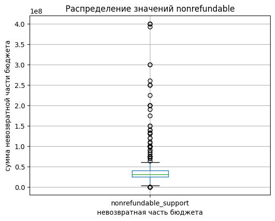

```python
# посторим график распределения значений невозвратной части бюджета
data['nonrefundable_support'].plot(kind = 'box', grid = True);
plt.title('Распределение значений nonrefundable')
plt.xlabel('невозвратная часть бюджета')
plt.ylabel('сумма невозвратной части бюджета');
```

Для данного набора данных минимальное значений равное 0 соответствует действительности и означает отсутствие суммы невозвратной части бюджета. Медианное значение составляет 30 млн, максимальная сумма - это 400 млн

```python
# сделаем проверку на корректность исходя из данных
data.query('nonrefundable_support + refundable_support > budget')['budget'].count()
```

```
17
```

```python
# заменим ошибочные значения на сумму nonrefundable_support и refundable_support
data.loc[data['nonrefundable_support'] + data['refundable_support'] > data['budget'], 'budget'] = \
data['nonrefundable_support'] + data['refundable_support']
```

- Описание столбца `budget` - общий бюджет фильмов с господдержкой

```python
data['budget'].describe()
```

```
count             332.00
mean      131,422,395.80
std       187,148,242.67
min         6,000,000.00
25%        45,524,799.50
50%        71,196,901.50
75%       150,000,000.00
max     2,305,074,303.00
Name: budget, dtype: float64
```

```python
# рассчитаем границы типичных значений
moustache(data['budget'])
```

```
(6000000.0, 306712800.75)
```

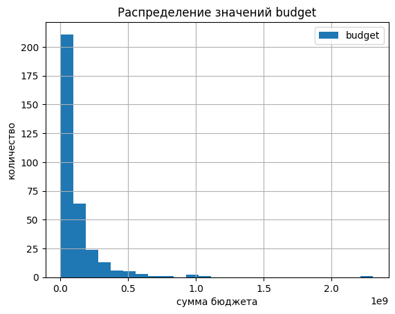

```python
# построим гистограмму распределения значений
data['budget'].hist(bins = 25, legend = True);
plt.title('Распределение значений budget')
plt.xlabel('сумма бюджета')
plt.ylabel('количество');
```

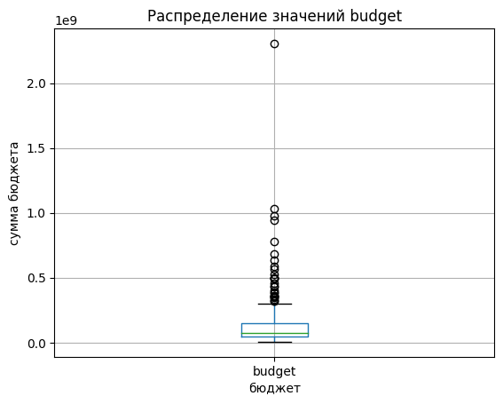

```python
# построим график для визуализации данных
data['budget'].plot(kind = 'box', grid = True);
plt.title('Распределение значений budget')
plt.xlabel('бюджет')
plt.ylabel('сумма бюджета');
```

Для фильмов с государственной поддержкой минимальный бюджет составляет 6 млн руб, максимальное же значение 2,30 млрд, что значительно превышает медиану.Верхняя граница нормальных значений - 306 млн.руб

- Рассмторим распределение значений кассового сбора

```python
# границы типичных значений столбца
moustache(data['box_office'])
```

```
(0.0, 59828509.25)
```

```python
data['box_office'].describe()
```

```
count           3,157.00
mean       76,502,859.66
std       240,387,362.16
min                 0.00
25%            86,190.00
50%         2,330,104.00
75%        23,983,117.70
max     3,073,568,690.79
Name: box_office, dtype: float64
```

Видим минимальное значение равное 0,удалим такие строки

```python
# удаление строк со значением box_office равным 0
data = data.loc[(data['box_office'] > 0)|(data['box_office'].isna()),:]
```

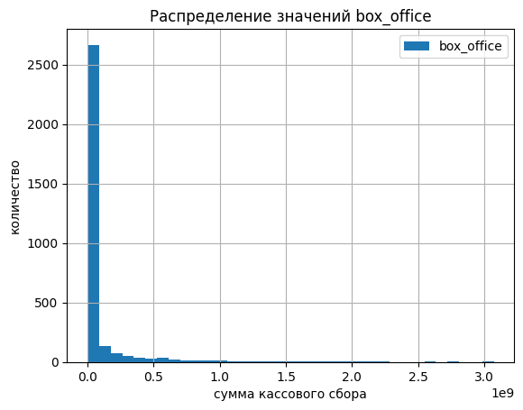

```python
data['box_office'].hist(bins = 35, legend = True);
plt.title('Распределение значений box_office')
plt.xlabel('сумма кассового сбора')
plt.ylabel('количество');
```

Анализируя гистограмму и показатели столбца можно придти к выводу о неком разделении значений.Одновременно большой обьем в самом начале гистограммы, резкое снижение в совокупности с длинным хвостом. Медиана и максимальное значение отличаются на 3 порядка.

Вывод:

```python
stop_row, a1 = data.shape
```

```python
print('Процент потерянных данных:',round(100 - (stop_row/start_row)*100, 2), '%')
```

```
Процент потерянных данных: 0.36 %
```

### Добавление параметров

```python
# добавим столбец с годом выдачи прокатного удостоверения
data['year_premier'] = data['show_start_date'].dt.year
```

```python
# напишем функцию для возврата ФИО главного режиссера
def direc(string):
    a = [i.strip() for i in string.split(',')]
    return (a[0])
```

```python
# создадим столбец с именем главного режиссера
data['main_director'] = data['director'].apply(direc)
```

```python
# создадим столбец с главным жанром фильма
data['main_genres'] = data['genres'].apply(direc)
```

```python
# создадим функцию для расчета доли государственного финансирования в бюджете, если госфинансирования нет, заполним 0
def perc(data):
    if data['budget'] > 0:
        return round((data['refundable_support'] + data['nonrefundable_support'])/data['budget'],2)
    else:
        return 0
```

```python
# создадим столбец с долей государственного финансирования в общем бюджете
data['gov_part'] = data.apply(perc, axis = 1)
```

### Исследовательский анализ данных

- Исследуем количество выданных прокатных удостоверений

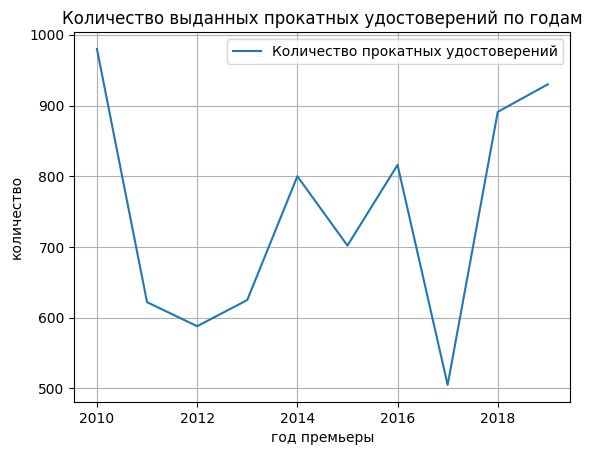

```python
# построим график зависимости количества удостоверений от года выдачи
data.pivot_table(index = 'year_premier', values = 'puNumber', aggfunc = 'count')\
.rename(columns ={'puNumber':'Количество прокатных удостоверений'})\
.plot(title = 'Количество выданных прокатных удостоверений по годам',grid = True);
plt.xlabel('год премьеры')
plt.ylabel('количество');
```

Количество прокатных удостоверений меняется от года к году, наблюдается некоторое падение в 2017г, максимум в 2010

- Посчитаем количество и долю прокатных удостоверний с имеющейся информацией о кассовых сборах

```python
#посчитаем количество прокатных удостоверений с указанной информацией о кассовых сборах
box_quantity = data.query('box_office.isna() == False')['box_office'].count()
# посчитаем процент прокатных удостоверений с информацией о кассовых сборах от общего числа прокатных удостоверений
per_quantity = (box_quantity/data['puNumber'].count())*100

print("Количество прокатных удостоверений с указанной суммой кассовых сборов: ",box_quantity )
print()
print('Доля прокатных удостоверений с указанной суммой кассовых сборов от общего количества: ',round(per_quantity,1),'%')
```

```
Количество прокатных удостоверений с указанной суммой кассовых сборов:  3133

Доля прокатных удостоверений с указанной суммой кассовых сборов от общего количества:  42.0 %
```

Доля прокатных удостоверений с указанной суммой сборов составляет 42%. Посчитаем как менялось количество прокатных удостоверений с информацией по кассовым сборам и без нее в течении 10 лет.

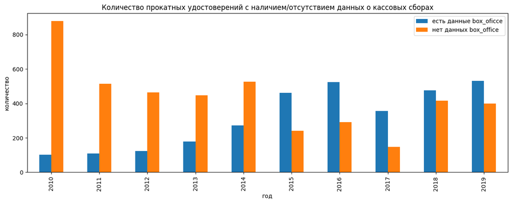

```python
# создадим сводную таблицу с наличием кассовых сборов сгруппированную по годам и найдем количество прокатных удостоверений
x = data.query('box_office.isna() == False').pivot_table(index = 'year_premier', values = 'puNumber', aggfunc = 'count')\
.rename(columns = {'puNumber':'есть данные box_oficce'})
# создадим сводную таблицу без сумм кассовых сборов сгруппированную по годам и найдем количество прокатных удостоверений
b = data.query('box_office.isna()').pivot_table(index = 'year_premier', values = 'puNumber', aggfunc = 'count')\
.rename(columns = {'puNumber':'нет данных box_office'})
# соединим полученные таблицы по году выпуска прокатных удостоверений и построим столбчатую диаграмму
x.merge(b, on = 'year_premier', how = 'outer')\
.plot(kind = 'bar',title = 'Количество прокатных удостоверений с наличием/отсутствием данных о кассовых сборах'\
      ,figsize = (15,5));
plt.xlabel('год')
plt.ylabel('количество');
```

Видим, что пропорция постепенно менялась и после 2014 года количество прокатных удостоверений с указанием кассового сбора начало превышать количество прокатных удостоверений без сборов.

```python
# создадим сводную таблицу,сгруппировав данные по году и рассчитаем количество данных для прокатных удостоверений с наличием
# данных по кассовым сборам и без
pivot_percent = data.pivot_table(index = 'year_premier', values = ['box_office','puNumber'],aggfunc ='count')\
.rename(columns = {'box_office': 'Количество данных с box_office','puNumber':'Общее количество'})
# добавим столбец с долей удостверений с информацией box_office от общего количества
pivot_percent['Доля данных с указанием box_office от общего количества'] = \
round((pivot_percent['Количество данных с box_office']/pivot_percent['Общее количество'])*100,1)
```

| year_premier | Количество данных с box_office | Общее количество | Доля данных с указанием box_office от общего количества |
| --- | --- | --- | --- |
| 2010 | 101 | 980 | 10.30 |
| 2011 | 109 | 622 | 17.50 |
| 2012 | 123 | 588 | 20.90 |
| 2013 | 179 | 625 | 28.60 |
| 2014 | 273 | 800 | 34.10 |
| 2015 | 462 | 702 | 65.80 |
| 2016 | 524 | 816 | 64.20 |
| 2017 | 357 | 505 | 70.70 |
| 2018 | 475 | 891 | 53.30 |
| 2019 | 530 | 930 | 57.00 |

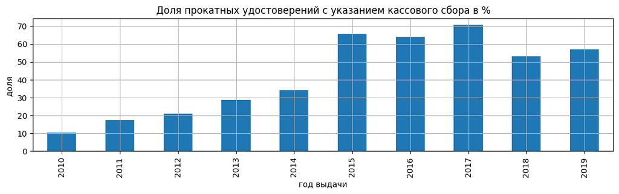

```python
# построим график изменения доли указанных box_office по годам
pivot_percent['Доля данных с указанием box_office от общего количества'].plot(kind = 'bar',\
grid = True, legend = False, title = "Доля прокатных удостоверений с указанием кассового сбора в %",\
xlabel = 'год выдачи', ylabel = 'доля ', figsize = (13,3) );
display(pivot_percent)
```

В процентом соотношении доля прокатных удостоверений с кассовыми сборами уверенно растет, наблюдается резкий скачек в 2015 году, максимум наблюдаем в 2017г. Если посмотореть на количественную представленность, то прокат без кассового сбора имеет в этом году минимум в количественном выражении. Можно сделать предположение о некоторых изменениях в выдаче прокатных удостоверений в целом в 2017 году, что привело к снижению их количества. Возможно изменение законодательства или наложение более строгих ограничений.

- Исследуем динамику продаж по годам:

```python
#создадим сводную таблицу и посчитаем суммарный кассовый сбор для каждого года
dinam_year = data.pivot_table(index = 'year_premier', values = 'box_office', aggfunc = 'sum')\
.rename(columns = {'box_office':'Сумма кассовых сборов'})
display(dinam_year)
```

| year_premier | Сумма кассовых сборов |
| --- | --- |
| 2010 | 2,428,654.00 |
| 2011 | 14,102,765.00 |
| 2012 | 6,955,423.00 |
| 2013 | 29,799,706.20 |
| 2014 | 7,444,951,859.20 |
| 2015 | 39,497,365,196.40 |
| 2016 | 47,866,105,214.91 |
| 2017 | 48,563,707,217.51 |
| 2018 | 49,668,403,134.32 |
| 2019 | 48,425,708,779.59 |

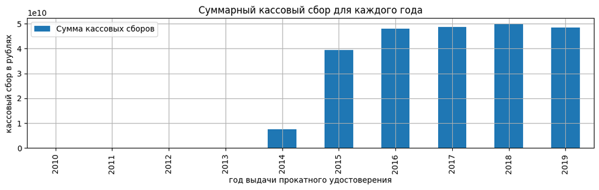

```python
# построим график суммарного кассового сбора
dinam_year.plot(kind = 'bar',grid = True, title = 'Суммарный кассовый сбор для каждого года',\
                xlabel = 'год выдачи прокатного удостоверения', ylabel = 'кассовый сбор в рублях', figsize = (13,3));
```

Как и предполгалось на графике видим провал до 2013 года.Из данных сводной таблицы можно увидеть, что до 2013 года включительно порядок исчесления иной. Попробуем проанализировать информацию в разрезе 2 периодов.

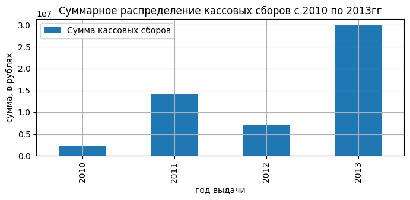

```python
# ввиду малых значений сборов в 2010-2013 построим дополнительную диаграмму
dinam_year.reset_index().query('year_premier < 2014').plot(kind = 'bar', x = 'year_premier',\
y = 'Сумма кассовых сборов', grid = True, title = 'Суммарное распределение кассовых сборов с 2010 по 2013гг',\
xlabel = 'год выдачи', ylabel = 'сумма, в рублях', figsize = (8,3));
```

В разрезе данных до 2013 года включительно, максимальный сбор был в 2013 году,этот год показывает и максимальный рост, минимальный сумма сборов была в 2010г

```python
# найдем год с максимальной суммой кассового сбора
print("Год с минимальным суммарным значение кассового сбора: ",dinam_year['Сумма кассовых сборов'].idxmin(),\
      "Сумма сборов: ",dinam_year['Сумма кассовых сборов'].min(), sep = '\n' )
print()
# найдем год с минимальной суммой кассового сбора
print("Год с максимальным суммарным значение кассового сбора: ",dinam_year['Сумма кассовых сборов'].idxmax(),\
     "Сумма сборов: ",dinam_year['Сумма кассовых сборов'].max(), sep = '\n')
```

```
Год с минимальным суммарным значение кассового сбора:
2010
Сумма сборов:
2428654.0

Год с максимальным суммарным значение кассового сбора:
2018
Сумма сборов:
49668403134.31999
```

Суммарный кассовый сбор начиная с 2015г. показывает примерно один уровень, максимум приходится на 2018 год. В 2010 - 2013 гг суммарный кассовый сбор был ничтожно мал по сравнению с периодом после 2014г и рассматривается отдельно, ввиду разности в методе исчесления.Минимальная сумма получена в 2010г, максимум в 2013.

- Посчитаем среднюю и медианную стоимость проката по годам

Рассмторим среднюю и медианную стоимость проката по годам, стоит обратить внимание на разность представленных данных и уитывать порядок подсчета для периода до 2014 и после.

|  | Год проката | Средняя стоимость проката по годам box_office | Медианная стоимость проката по годам box_office |
| --- | --- | --- | --- |
| 0 | 2010 | 24,046.08 | 1,710.00 |
| 1 | 2011 | 129,383.17 | 3,000.00 |
| 2 | 2012 | 56,548.15 | 6,220.00 |
| 3 | 2013 | 166,478.81 | 3,580.00 |
| 4 | 2014 | 27,270,885.93 | 20,400.00 |
| 5 | 2015 | 85,492,132.46 | 5,003,450.15 |
| 6 | 2016 | 91,347,529.04 | 3,957,926.01 |
| 7 | 2017 | 136,032,793.33 | 9,968,340.00 |
| 8 | 2018 | 104,565,059.23 | 8,891,102.21 |
| 9 | 2019 | 91,369,261.85 | 4,627,798.34 |

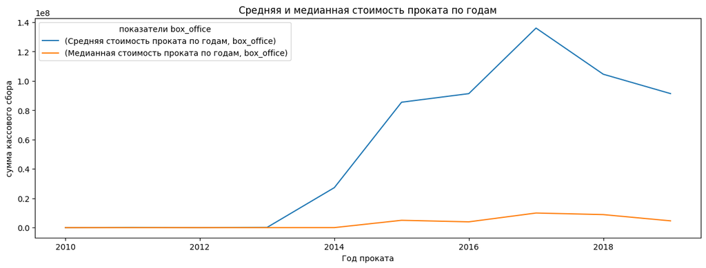

```python
# создадим сводную таблицу сгруппировав данные по году выпуска и посчитаем среднюю и медианную стоимость кассовых сборов
data_med = data.query('box_office.isna() == False')\
.pivot_table(index = 'year_premier', values = 'box_office', aggfunc = ['mean', 'median']).reset_index()\
.rename(columns = {'year_premier':'Год проката','mean':'Средняя стоимость проката по годам',\
                   'median':'Медианная стоимость проката по годам'})
display(data_med)
# построим график медианной и средней стоимости по годам
data_med.plot(x = 'Год проката', y = ['Средняя стоимость проката по годам','Медианная стоимость проката по годам'], \
              title = 'Средняя и медианная стоимость проката по годам',figsize = (15,5));
plt.legend(title = 'показатели box_office')
plt.ylabel('сумма кассового сбора');
```

Ожидаемо видим провал в данных до 2014г, обратившись к таблице можно увидеть числовые значения и определить, что в 2010 году медианная стоимость была минимальной, как и средняя. Максимальная медианная была в 2012, средняя же в 2013 году. Разница между медианой и средним арифметическим достаточно большая, что тговорит о наличии сверх больших кассовых сборов. После 2014 года максимальная средняя и медианная стоимость приходится на 2017 год, минимум на 2014 год.

- Исследование влияния возрастного ограничения на кассовые сборы после 2014г

```python
# сгруппировав данные по возрастному ограничению, посчитаем суммарный кассовый сбор, медианная стоимость и общее количество
data_age = data.query('year_premier > 2014')\
.pivot_table(index = 'age_restriction', values = 'box_office', aggfunc = ['sum', 'median', 'count']).reset_index()\
.rename(columns = {'age_restriction':'Возрастное ограничение',"sum":"Суммарный кассовый сбор",\
                   "median":"Медианная стоимость кассовых сборов", 'count':'Общее количество'})
data_age.sort_values(by = ('Общее количество','box_office'))
```

|  | Возрастное ограничение | Суммарный кассовый сбор box_office | Медианная стоимость кассовых сборов box_office | Общее количество box_office |
| --- | --- | --- | --- | --- |
| 0 | «0+» - для любой зрительской аудитории | 808,882,898.97 | 2,955,934.60 | 89 |
| 4 | «6+» - для детей старше 6 лет | 55,798,610,799.68 | 13,736,207.98 | 317 |
| 1 | «12+» - для детей старше 12 лет | 60,619,446,628.33 | 5,175,580.50 | 347 |
| 3 | «18+» - запрещено для детей | 40,759,615,572.12 | 6,154,439.17 | 792 |
| 2 | «16+» - для детей старше 16 лет | 76,034,733,643.63 | 5,604,702.00 | 803 |

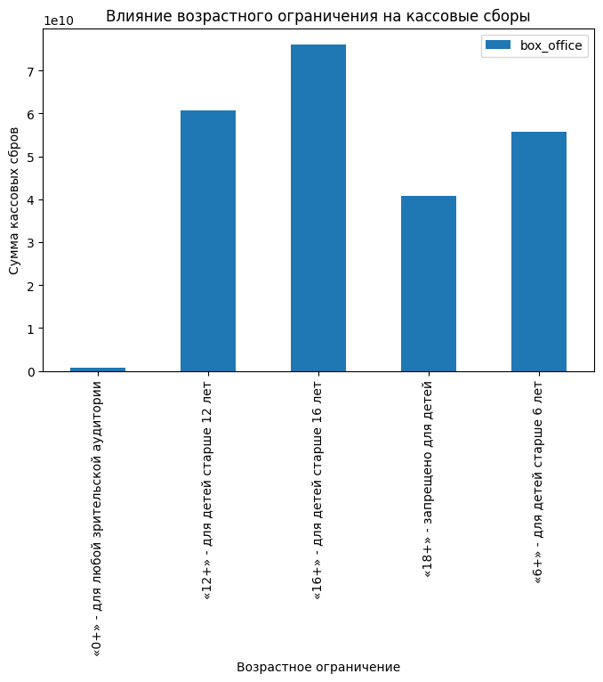

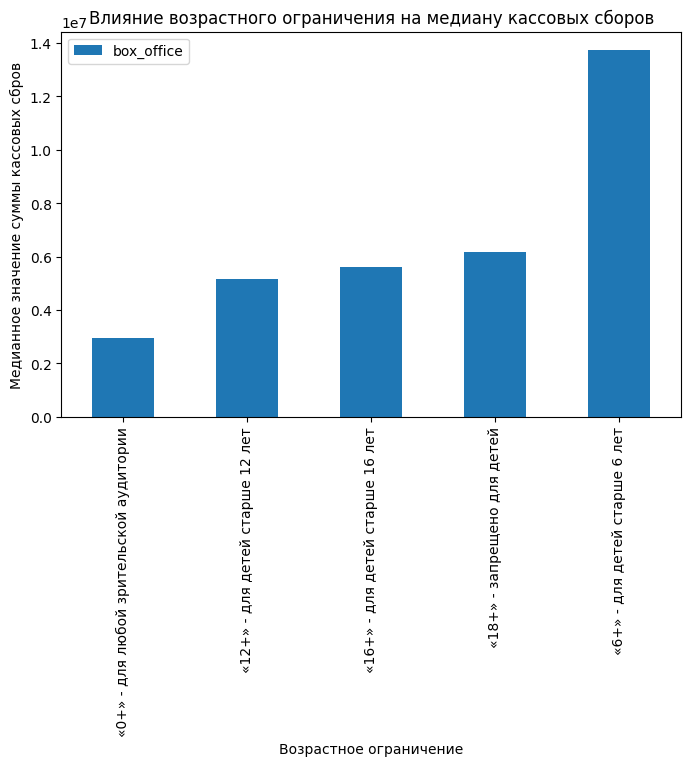

```python
data_age.plot(kind = 'bar', x = 'Возрастное ограничение', y = 'Суммарный кассовый сбор',figsize = (8,5))
plt.title("Влияние возрастного ограничения на кассовые сборы")
plt.ylabel('Сумма кассовых сбров')

data_age.plot(kind = 'bar', x = 'Возрастное ограничение', y = "Медианная стоимость кассовых сборов",figsize = (8,5))
plt.title("Влияние возрастного ограничения на медиану кассовых сборов")
plt.ylabel('Медианное значение суммы кассовых сбров');
```

Фильмы для любой зрительской аудитории имеют самые низкие сборы,как по суммарному, так и медианному значениям, количество также является наименьшим. Самый высокий суммарный кассовый сбор у возрастной группы 16+, учитывая средний уровень медианной стоимости для этой группы, можно сказать о влиянии на показатель количества фильмов с таким возрастным ограничением.Наибольшее медианное значение у фильмов 6+ при среднем количестве и суммарной годовой стоимости очевидно говорит о высокой посещаемости(либо стоимости входных билетов).Количество фильмов 18+ хотя и показывает большое значение, но суммарный кассовый сбор один из самых низких.

### Исследовательский анализ данных фильмов с государственной поддержкой

Создадим новую переменную, где оставим только фильмы с государственной поддержкой

```python
gov_data = data.loc[data['financing_source']!= 'Иное финансирование',:]
```

```python
gov_data.info()
```

```
<class 'pandas.core.frame.DataFrame'>
Int64Index: 332 entries, 1281 to 7478
Data columns (total 20 columns):
 #   Column                 Non-Null Count  Dtype
---  ------                 --------------  -----
 0   title                  332 non-null    object
 1   puNumber               332 non-null    float64
 2   show_start_date        332 non-null    datetime64[ns, UTC]
 3   type                   332 non-null    object
 4   film_studio            332 non-null    object
 5   production_country     332 non-null    object
 6   director               332 non-null    object
 7   producer               330 non-null    object
 8   age_restriction        332 non-null    object
 9   refundable_support     332 non-null    float64
 10  nonrefundable_support  332 non-null    float64
 11  budget                 332 non-null    float64
 12  financing_source       332 non-null    object
 13  ratings                316 non-null    float64
 14  genres                 332 non-null    object
 15  box_office             318 non-null    float64
 16  year_premier           332 non-null    int64
 17  main_director          332 non-null    object
 18  main_genres            332 non-null    object
 19  gov_part               332 non-null    float64
dtypes: datetime64[ns, UTC](1), float64(7), int64(1), object(11)
memory usage: 54.5+ KB
```

```python
# удалим строки с пропусками в 'box_office'
gov_data = gov_data.dropna(subset = ['box_office'])
```

```python
print('Процент потерь:', round((14/332)*100,1), '%')
```

```
Процент потерь: 4.2 %
```

Сделаем некоторую визульную оценку фильмам без господдержки, произведенным в России после 2012г

```python
# рассчитаем количество фильмов Росии без господдержки после 2013 года
data.loc[(data['production_country'] == 'Россия')&(data['budget'].isna())&(data['year_premier'] > 2012)]['box_office']\
.count()
```

```
345
```

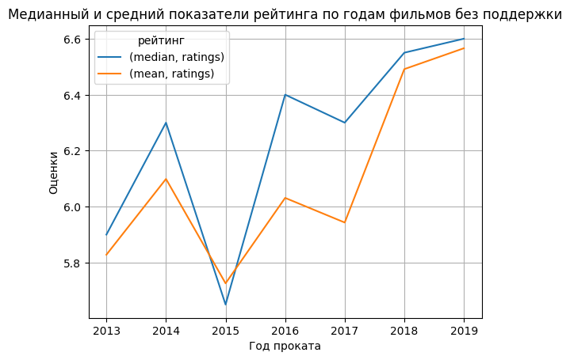

```python
# построим график зависимости рейтинга от года проката фильмов без господдержки после 2012
data.loc[(data['production_country'] == 'Россия')&(data['budget'].isna())&(data['year_premier'] > 2012)]\
.pivot_table(index = 'year_premier',values = 'ratings', aggfunc = ['median','mean'])\
.plot(grid = True, legend = True, title = 'Медианный и средний показатели рейтинга по годам фильмов без поддержки'\
     ,xlabel = 'Год проката', ylabel = "Оценки")
plt.legend(title = 'рейтинг');
```

```python
# создадим таблицу зависимости показателей кассовго сбора от года проката фильмов России без господдержки после 2012
non_gov = data.loc[(data['production_country'] == 'Россия')&(data['budget'].isna())&(data['year_premier'] > 2012)]\
.pivot_table(index = "year_premier",values = 'box_office',aggfunc = ['mean','median','sum'])\
.reset_index()\
.rename(columns = {"year_premier":'год проката','mean':'Средний показатель кассового сбора',\
                   'median':"Медианный показатель кассового сбора",'sum':"Суммарный вес кассовых сборов"})
non_gov
```

|  | год проката | Средний показатель кассового сбора box_office | Медианный показатель кассового сбора box_office | Суммарный вес кассовых сборов box_office |
| --- | --- | --- | --- | --- |
| 0 | 2013 | 58,180.31 | 7,525.00 | 2,734,474.60 |
| 1 | 2014 | 12,376,166.54 | 36,802.00 | 693,065,326.30 |
| 2 | 2015 | 23,764,094.56 | 2,384,385.63 | 1,093,148,349.85 |
| 3 | 2016 | 18,785,497.14 | 2,186,272.00 | 1,371,341,291.58 |
| 4 | 2017 | 36,011,324.88 | 3,648,777.50 | 468,147,223.46 |
| 5 | 2018 | 59,461,518.99 | 1,833,102.00 | 3,567,691,139.38 |
| 6 | 2019 | 57,835,955.50 | 2,496,173.25 | 2,891,797,774.92 |

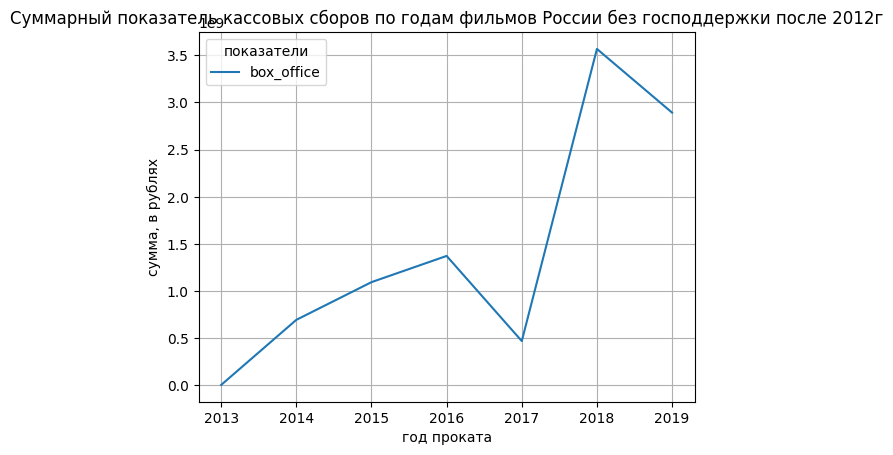

```python
# построим график зависимости показателей кассовго сбора от года проката фильмов России без господдержки после 2012
non_gov.plot( x = "год проката",y = "Суммарный вес кассовых сборов",\
             grid = True,\
             ylabel = 'сумма, в рублях',\
             title = 'Суммарный показатель кассовых сборов по годам фильмов России без господдержки после 2012г',)
plt.legend(title = 'показатели');
```

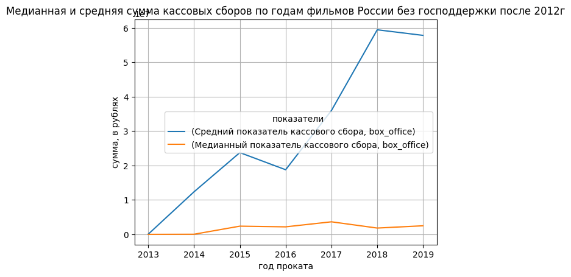

```python
# построим график зависимости показателей кассовго сбора от года проката фильмов России без господдержки после 2012
non_gov.plot( x = "год проката",y = ['Средний показатель кассового сбора',"Медианный показатель кассового сбора"],\
             grid = True,\
             ylabel = 'сумма, в рублях',\
             title = 'Медианная и средняя сумма кассовых сборов по годам фильмов России без господдержки после 2012г',)
plt.legend(title = 'показатели');
```

Данные российского кино без господдержки сравним с фильмами, финансирующимися госструктурами для общего вывода.

- Оценим количество фильмов с господдержкой относительно года выдачи

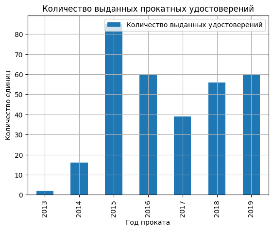

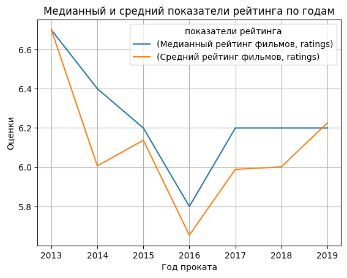

```python
#построим диаграмму зависимомти года и количества прокатных удостоверений, рейтинга фильмов
gov_data.pivot_table(index = 'year_premier',values = 'puNumber', aggfunc = 'count')\
.rename(columns = {'puNumber':'Количество выданных удостоверений'})\
.plot(kind = 'bar', grid = True, legend = True, title = 'Количество выданных прокатных удостоверений'\
      ,xlabel = 'Год проката', ylabel = "Количество единиц");

gov_data.pivot_table(index = 'year_premier',values = 'ratings', aggfunc = ['median','mean'])\
.rename(columns = {'median':'Медианный рейтинг фильмов', 'mean':'Средний рейтинг фильмов'},level = 0)\
.plot(grid = True, legend = True, title = 'Медианный и средний показатели рейтинга по годам'\
     ,xlabel = 'Год проката', ylabel = "Оценки")
plt.legend(title = 'показатели рейтинга');
```

```python
gov_data['ratings'].describe()
```

```
count   303.00
mean      6.02
std       1.16
min       1.00
25%       5.35
50%       6.20
75%       6.70
max       9.40
Name: ratings, dtype: float64
```

Наибольшее количество фильмов с господдержкой вышло в 2015 году, более 80 штук, наименьшее в 2013.При этом фильмы в 2013 получили в среднем и меданным значениеми наиболее высокую оценку зрителей, что скорее всего связано со сверхмалой выборкой.2016 год показывает самые низкие баллы рейтинга.

```python
# создадим переменную, в которую запишем сводную таблицу, сгруппировав данные по году, где значения это
# средний, медианный и суммарный показатели
gov_box = gov_data.pivot_table(index = "year_premier",values = 'box_office',aggfunc = ['mean','median','sum'])\
.reset_index()\
.rename(columns = {"year_premier":'год проката','mean':'Средний показатель кассового сбора',\
                   'median':"Медианный показатель кассового сбора",'sum':"Суммарный вес кассовых сборов"})
gov_box
```

|  | год проката | Средний показатель кассового сбора box_office | Медианный показатель кассового сбора box_office | Суммарный вес кассовых сборов box_office |
| --- | --- | --- | --- | --- |
| 0 | 2013 | 10,161,192.55 | 10,161,192.55 | 20,322,385.10 |
| 1 | 2014 | 63,588,885.41 | 5,504,517.85 | 1,017,422,166.60 |
| 2 | 2015 | 68,062,181.39 | 9,200,824.50 | 5,785,285,418.14 |
| 3 | 2016 | 101,361,797.32 | 17,921,115.61 | 6,081,707,839.10 |
| 4 | 2017 | 278,591,674.38 | 50,451,949.00 | 10,865,075,300.96 |
| 5 | 2018 | 177,394,089.47 | 27,023,390.31 | 9,934,069,010.25 |
| 6 | 2019 | 140,160,457.58 | 25,977,291.30 | 8,409,627,454.63 |

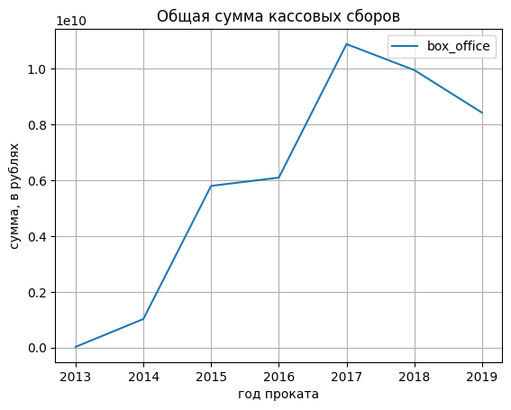

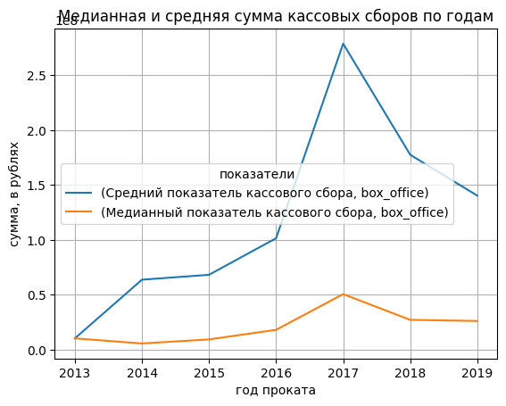

```python
# построим график зависимости суммарного кассового сбора года проката
gov_box.plot( x = "год проката",y = "Суммарный вес кассовых сборов", grid = True,\
             ylabel = 'сумма, в рублях',title = 'Общая сумма кассовых сборов');
# построим график зависимости медианного и среднего показателя от года проката
gov_box.plot( x = "год проката",y = ['Средний показатель кассового сбора',"Медианный показатель кассового сбора"],\
             grid = True,\
             ylabel = 'сумма, в рублях',title = 'Медианная и средняя сумма кассовых сборов по годам',)
plt.legend(title = 'показатели');
```

```python
print("Самый высокий суммарный кассовый сбор:", int(gov_box['Суммарный вес кассовых сборов'].max()),\
     'в', int(gov_box['год проката'][gov_box['Суммарный вес кассовых сборов'].idxmax()]), 'году')
print()
print("Самый высокий медианный показатель кассового сбора:", int(gov_box['Медианный показатель кассового сбора'].max()),\
      'в', int(gov_box['год проката'][gov_box['Медианный показатель кассового сбора'].idxmax()]), 'году')
print()
print("Самый высокий средний показатель кассового сбора:", int(gov_box['Средний показатель кассового сбора'].max()),\
      'в', int(gov_box['год проката'][gov_box['Средний показатель кассового сбора'].idxmax()]), 'году')
```

```
Самый высокий суммарный кассовый сбор: 10865075300 в 2017 году

Самый высокий медианный показатель кассового сбора: 50451949 в 2017 году

Самый высокий средний показатель кассового сбора: 278591674 в 2017 году
```